# Herpailurus yagouaroundi Variable Selection

Author

Florencia Grattarola

Published

March 17, 2023

- R Libraries

```r
library(knitr)
library(dismo)
library(gbm)
library(randomForest)
library(ranger) # for the Random Forest
library(terra)
terraOptions(tempdir='big_data/temp')
library(sf)
library(tidyverse)
```

- `bio1`: Annual Mean Temperature, from Bioclimatic variables (WorldClim V2.1)
- `bio2`: Mean Diurnal Range (Mean of monthly (max temp - min temp)), from Bioclimatic variables (WorldClim V2.1)
- `bio3`: Isothermality (BIO2/BIO7) (×100), from Bioclimatic variables (WorldClim V2.1)
- `bio4`: Temperature Seasonality (standard deviation ×100), from Bioclimatic variables (WorldClim V2.1)
- `bio5`: Max Temperature of Warmest Month, from Bioclimatic variables (WorldClim V2.1)
- `bio6`: Min Temperature of Coldest Month, from Bioclimatic variables (WorldClim V2.1)
- `bio7`: Temperature Annual Range (BIO5-BIO6), from Bioclimatic variables (WorldClim V2.1)
- `bio8`: Mean Temperature of Wettest Quarter, from Bioclimatic variables (WorldClim V2.1)
- `bio9`: Mean Temperature of Driest Quarter, from Bioclimatic variables (WorldClim V2.1)
- `bio10`: Mean Temperature of Warmest Quarter, from Bioclimatic variables (WorldClim V2.1)
- `bio11`: Mean Temperature of Coldest Quarter, from Bioclimatic variables (WorldClim V2.1)
- `bio12`: Annual Precipitation, from Bioclimatic variables (WorldClim V2.1)
- `bio13`: Precipitation of Wettest Month, from Bioclimatic variables (WorldClim V2.1)
- `bio14`: Precipitation of Driest Month, from Bioclimatic variables (WorldClim V2.1)
- `bio15`: Precipitation Seasonality (Coefficient of Variation), from Bioclimatic variables (WorldClim V2.1)
- `bio16`: Precipitation of Wettest Quarter, from Bioclimatic variables (WorldClim V2.1)
- `bio17`: Precipitation of Driest Quarter, from Bioclimatic variables (WorldClim V2.1)
- `bio18`: Precipitation of Warmest Quarter, from Bioclimatic variables (WorldClim V2.1)
- `bio19`: Precipitation of Coldest Quarter, from Bioclimatic variables (WorldClim V2.1)
- `elev`: Elevation (WorldClim V2.1 SRTM elevation data), from Bioclimatic variables (WorldClim V2.1)
- `urban`: Urban and Built-up Lands, from Land cover LC1 (MODIS TERRA LandCover_Type_Yearly_500m (MCD12Q1))
- `barren`: Barren, from Land cover LC1 (MODIS TERRA LandCover_Type_Yearly_500m (MCD12Q1))
- `water`: Water Bodies, from Land cover LC1 (MODIS TERRA LandCover_Type_Yearly_500m (MCD12Q1))
- `savanna`: Savannas, from Land cover LC1 (MODIS TERRA LandCover_Type_Yearly_500m (MCD12Q1))
- `woodysavanna`: Woody savannas, from Land cover LC1 (MODIS TERRA LandCover_Type_Yearly_500m (MCD12Q1))
- `wetland`: Permanent Wetlands, from Land cover LC1 (MODIS TERRA LandCover_Type_Yearly_500m (MCD12Q1))
- `grass`: Grasslands, from Land cover LC1 (MODIS TERRA LandCover_Type_Yearly_500m (MCD12Q1))
- `npp`: Net Primary Production (NPP) (MODIS TERRA Net_PP_GapFil_Yearly_500m (M*D17A3HGF))
- `tree`: Percentage of Tree Cover, from Vegetation Continuous Fields (MODIS TERRA Veg_Cont_Fields_Yearly_250m (MOD44B))
- `nontree`: Percentage of No Tree Cover, from Vegetation Continuous Fields (MODIS TERRA Veg_Cont_Fields_Yearly_250m (MOD44B))
- `nonveg`: Percentage of Non Tree Vegetation Cover, from Vegetation Continuous Fields (MODIS TERRA Veg_Cont_Fields_Yearly_250m (MOD44B))

```r
bio <- rast('big_data/bio_high.tif')
elev <- rast('big_data/elev_high.tif')
urban <- rast('big_data/urban_high.tif') %>% resample(., elev)
```

```
|---------|---------|---------|---------|
=========================================
```

```r
barren  <- rast('big_data/barren_high.tif') %>% resample(., elev)
```

```
|---------|---------|---------|---------|
=========================================
```

```r
water <- rast('big_data/water_high.tif') %>% resample(., elev)
```

```
|---------|---------|---------|---------|
=========================================
```

```r
savanna <- rast('big_data/savanna_high.tif') %>% resample(., elev)
```

```
|---------|---------|---------|---------|
=========================================
```

```r
woodysavanna <- rast('big_data/woodysavanna_high.tif') %>% resample(., elev)
```

```
|---------|---------|---------|---------|
=========================================
```

```r
wetland <- rast('big_data/wetland_high.tif') %>% resample(., elev)
```

```
|---------|---------|---------|---------|
=========================================
```

```r
grass <- rast('big_data/grass_high.tif') %>% resample(., elev)
```

```
|---------|---------|---------|---------|
=========================================
```

```r
npp <- rast('big_data/npp_high.tif') %>% resample(., elev)
```

```
|---------|---------|---------|---------|
=========================================
```

```r
names(npp) <- 'npp'
tree <- rast('big_data/tree_high.tif') %>% resample(., elev)
```

```
|---------|---------|---------|---------|
=========================================
```

```r
nontree <- rast('big_data/nontree_high.tif') %>% resample(., elev)
```

```
|---------|---------|---------|---------|
=========================================
```

```r
nonveg <- rast('big_data/nonveg_high.tif') %>% resample(., elev)
```

```
|---------|---------|---------|---------|
=========================================
```

```r
env <- c(bio, elev, urban, barren, water,
         savanna, woodysavanna, wetland,
         grass, npp, tree, nontree, nonveg) %>% scale()
```

```
|---------|---------|---------|---------|
=========================================


|---------|---------|---------|---------|
=========================================
```

```r
rm(bio, elev, urban, barren, water,
         savanna, woodysavanna, wetland,
         grass, npp, tree, nontree, nonveg)

gc()
```

```
          used  (Mb) gc trigger  (Mb) limit (Mb) max used  (Mb)
Ncells 4232462 226.1    7292315 389.5         NA  7292315 389.5
Vcells 6109933  46.7   12255594  93.6     102400  8673989  66.2
```

## Species’ preferences

### Yaguarundí

- It occurs in a variety of habitats, from closed primary rainforest to open desert, scrub, and grassland, although in open areas it sticks to patches of dense cover.
- Caso and Tewes (2007) found that radio-collared jaguarundis used mature forest 53% of the time and pasture-grassland 47% of the time. It is predominantly a lowland species ranging up to 2000 m, although it was reported up to 3200 m in Colombia (Cuervo et al. 1986).
- Yaguarundís occur at relatively low densities of 1–5/100 km2 in Brazil (Oliveira et al. 2008), but reach densities up to 20/100 km2 in Tamaulipas, Mexico. Although with its wide range the species is classified as Least Concern, habitat loss is a threat, especially for the more open types, which are being converted to large-scale agriculture (IUCN 2008).

## Species data

```r
PA_time1 <- readRDS('data/PA_hyagouaroundi_time1_blobs.rds')%>% ungroup()
PA_time2 <- readRDS('data/PA_hyagouaroundi_time2_blobs.rds')%>% ungroup()

PA_time1 %>% st_drop_geometry() %>% head() %>% kable()
```

| ID | presence | temporalSpan | effort | blobArea |
| --- | --- | --- | --- | --- |
| 1 | 0 | 1365 days | 1043 | 241873943 [m^2] |
| 2 | 1 | 1769 days | 2404 | 537081878 [m^2] |
| 3 | 1 | 6222 days | 11078 | 2241827859 [m^2] |
| 4 | 1 | 720 days | 1291 | 162791738 [m^2] |
| 5 | 0 | 1769 days | 1779 | 756798182 [m^2] |
| 6 | 1 | 304 days | 3300 | 19990863 [m^2] |

```r
PA_time2 %>% st_drop_geometry() %>% head() %>% kable()
```

| ID | presence | temporalSpan | effort | blobArea |
| --- | --- | --- | --- | --- |
| 1 | 0 | 510 days | 11095 | 2.229446e+09 [m^2] |
| 2 | 1 | 510 days | 9265 | 2.991334e+08 [m^2] |
| 3 | 1 | 4745 days | 390 | 2.351660e+08 [m^2] |
| 4 | 0 | 365 days | 30 | 7.849412e+07 [m^2] |
| 5 | 1 | 488 days | 5344 | 7.496574e+03 [m^2] |
| 6 | 1 | 488 days | 3282 | 3.298492e+03 [m^2] |

Presence-absence data for the second period

## Preparation of data for the tests

```r
# combine pre and pos datasets
PA.data <- st_join(PA_time1, PA_time2 %>% dplyr::select(presence), left = T) %>%
  group_by(ID) %>%
  mutate(presence=max(presence.x, presence.y, na.rm = T))

# calculate area, coordinates, and extract env predictors for each blob
PA.coords <- st_coordinates(st_centroid(PA.data)) %>% as_tibble()
PA.area <- as.numeric(PA.data$blobArea)

PA.env <- terra::extract(x = env, y = vect(PA.data),
                         fun = mean, rm.na=T) %>%
  mutate(across(where(is.numeric), ~ifelse(is.nan(.), NA, .)))

## the data
PA <- data.frame(PA.coords,
                 area = PA.area,
                 presabs = PA.data$presence,
                 env = PA.env)
```

### Correlation between variables

```r
PA %>% filter(!if_any(everything(), is.na)) %>% dplyr::select(-c(1:5)) %>% cor() %>% kable()
```

|  | env.bio_1 | env.bio_2 | env.bio_3 | env.bio_4 | env.bio_5 | env.bio_6 | env.bio_7 | env.bio_8 | env.bio_9 | env.bio_10 | env.bio_11 | env.bio_12 | env.bio_13 | env.bio_14 | env.bio_15 | env.bio_16 | env.bio_17 | env.bio_18 | env.bio_19 | env.elev | env.urban | env.barren | env.water | env.savanna | env.woodysavanna | env.wetland | env.grass | env.npp | env.tree | … |
| --- | --- | --- | --- | --- | --- | --- | --- | --- | --- | --- | --- | --- | --- | --- | --- | --- | --- | --- | --- | --- | --- | --- | --- | --- | --- | --- | --- | --- | --- | --- |
| env.bio_1 | 1.0000000 | 0.9410376 | 0.9725134 | 0.2967630 | 0.4080701 | -0.0301558 | 0.2521650 | 0.4420920 | -0.0420696 | -0.1338145 | 0.2236097 | -0.2388933 | 0.6816248 | -0.7074880 | 0.8380369 | 0.9212223 | -0.5795512 | 0.8823799 | 0.8850827 | -0.7020268 | -0.2166950 | -0.1465310 | 0.2809243 | -0.0095489 | 0.0164349 | 0.1900006 | -0.0951956 | -0.4904385 | 0.2909198 | … |
| env.bio_2 | 0.9410376 | 1.0000000 | 0.8471842 | 0.1536103 | 0.1794770 | -0.0069825 | 0.1415631 | 0.2199169 | -0.0165252 | -0.2125705 | 0.1964657 | -0.1900624 | 0.4609086 | -0.4396561 | 0.9131318 | 0.8149834 | -0.3878905 | 0.8562405 | 0.8105774 | -0.8204205 | -0.2349732 | -0.1290118 | 0.2667949 | 0.0367209 | 0.0383423 | 0.2310969 | -0.1597560 | -0.5634650 | 0.2588505 | … |
| env.bio_3 | 0.9725134 | 0.8471842 | 1.0000000 | 0.3928613 | 0.5193192 | -0.0002339 | 0.2753921 | 0.5581876 | -0.0122189 | -0.1299641 | 0.2782420 | -0.2910995 | 0.7982923 | -0.8490147 | 0.7453691 | 0.9554377 | -0.6910522 | 0.8208304 | 0.9030990 | -0.6039248 | -0.1800258 | -0.1401912 | 0.3048157 | -0.0332101 | 0.0016211 | 0.1339512 | -0.1035231 | -0.3818775 | 0.3412311 | … |
| env.bio_4 | 0.2967630 | 0.1536103 | 0.3928613 | 1.0000000 | 0.7978048 | 0.7241601 | -0.4279629 | 0.8328611 | 0.7247224 | 0.3861025 | 0.7283618 | -0.6012154 | 0.5382832 | -0.5161658 | -0.0448003 | 0.5072261 | -0.6870360 | 0.1976613 | 0.3604026 | -0.2848498 | 0.0336681 | -0.1767300 | 0.3146727 | -0.3691657 | -0.1278214 | -0.1199020 | -0.1421615 | 0.2372008 | 0.5738663 | … |
| env.bio_5 | 0.4080701 | 0.1794770 | 0.5193192 | 0.7978048 | 1.0000000 | 0.2432690 | 0.1286450 | 0.9847344 | 0.2349485 | 0.4209210 | 0.4409867 | -0.3663913 | 0.6636110 | -0.7002886 | 0.0322553 | 0.5261694 | -0.6554730 | 0.3305277 | 0.4021549 | -0.1179441 | 0.0450232 | -0.2050553 | 0.2408302 | -0.3398891 | -0.0646217 | -0.1007284 | 0.0906502 | 0.1071877 | 0.3874699 | … |
| env.bio_6 | -0.0301558 | -0.0069825 | -0.0002339 | 0.7241601 | 0.2432690 | 1.0000000 | -0.8239212 | 0.2798306 | 0.9959224 | 0.2094136 | 0.7680830 | -0.6446470 | 0.1819086 | -0.0133588 | -0.2279429 | 0.2190161 | -0.4482703 | -0.0860579 | 0.0886227 | -0.2763418 | -0.0043958 | -0.0556343 | 0.3366258 | -0.2999739 | -0.0944336 | -0.0546352 | -0.2967035 | 0.2916873 | 0.5563343 | … |
| env.bio_7 | 0.2521650 | 0.1415631 | 0.2753921 | -0.4279629 | 0.1286450 | -0.8239212 | 1.0000000 | 0.0969933 | -0.8380090 | -0.1030469 | -0.5529872 | 0.4822450 | 0.2047310 | -0.3244281 | 0.2926534 | 0.0706971 | 0.1214860 | 0.2776797 | 0.1350802 | 0.2409236 | 0.0006525 | -0.0416881 | -0.1903310 | 0.1878727 | 0.1607361 | 0.0234546 | 0.2110834 | -0.2081632 | -0.3393455 | … |
| env.bio_8 | 0.4420920 | 0.2199169 | 0.5581876 | 0.8328611 | 0.9847344 | 0.2798306 | 0.0969933 | 1.0000000 | 0.2717198 | 0.3909086 | 0.4786770 | -0.4136770 | 0.6815274 | -0.7284358 | 0.0708025 | 0.5762819 | -0.6921163 | 0.3499530 | 0.4498854 | -0.1662657 | 0.0576038 | -0.2054772 | 0.2618781 | -0.3206388 | -0.0500857 | -0.1171249 | -0.0004114 | 0.1210585 | 0.4380999 | … |
| env.bio_9 | -0.0420696 | -0.0165252 | -0.0122189 | 0.7247224 | 0.2349485 | 0.9959224 | -0.8380090 | 0.2717198 | 1.0000000 | 0.2131532 | 0.7690611 | -0.6380509 | 0.1689528 | -0.0026553 | -0.2353018 | 0.2063046 | -0.4372172 | -0.0937985 | 0.0730490 | -0.2754929 | -0.0046127 | -0.0593554 | 0.3290610 | -0.3001513 | -0.0989210 | -0.0569243 | -0.3059837 | 0.3069575 | 0.5551067 | … |
| env.bio_10 | -0.1338145 | -0.2125705 | -0.1299641 | 0.3861025 | 0.4209210 | 0.2094136 | -0.1030469 | 0.3909086 | 0.2131532 | 1.0000000 | -0.0836417 | -0.1909741 | -0.0328000 | 0.0174211 | -0.4168521 | -0.1190670 | -0.1493446 | 0.0888354 | -0.3218659 | 0.1296663 | 0.2575487 | -0.1625231 | -0.1344434 | -0.2577892 | 0.0250223 | -0.0628819 | 0.1016193 | 0.3063098 | -0.0024718 | … |
| env.bio_11 | 0.2236097 | 0.1964657 | 0.2782420 | 0.7283618 | 0.4409867 | 0.7680830 | -0.5529872 | 0.4786770 | 0.7690611 | -0.0836417 | 1.0000000 | -0.6480797 | 0.4482400 | -0.2869769 | 0.0167487 | 0.4780386 | -0.6046402 | 0.0558561 | 0.3940552 | -0.3826257 | -0.0806428 | -0.0448267 | 0.4306989 | -0.3166075 | -0.0767622 | -0.0489669 | -0.2648641 | 0.1158628 | 0.6234826 | … |
| env.bio_12 | -0.2388933 | -0.1900624 | -0.2910995 | -0.6012154 | -0.3663913 | -0.6446470 | 0.4822450 | -0.4136770 | -0.6380509 | -0.1909741 | -0.6480797 | 1.0000000 | -0.3076015 | 0.3075384 | 0.1615340 | -0.5344862 | 0.8070542 | -0.1695605 | -0.3016939 | 0.4473528 | -0.0916723 | 0.0675451 | -0.4338277 | 0.3453432 | 0.0343989 | -0.1135549 | 0.3663237 | -0.1799779 | -0.6702923 | … |
| env.bio_13 | 0.6816248 | 0.4609086 | 0.7982923 | 0.5382832 | 0.6636110 | 0.1819086 | 0.2047310 | 0.6815274 | 0.1689528 | -0.0328000 | 0.4482400 | -0.3076015 | 1.0000000 | -0.8963275 | 0.3525274 | 0.8052552 | -0.7827972 | 0.4984280 | 0.7359857 | -0.2526559 | -0.1258845 | -0.0504281 | 0.3448804 | -0.1878403 | -0.0259867 | -0.0211270 | -0.0405427 | -0.1365617 | 0.3851563 | … |
| env.bio_14 | -0.7074880 | -0.4396561 | -0.8490147 | -0.5161658 | -0.7002886 | -0.0133588 | -0.3244281 | -0.7284358 | -0.0026553 | 0.0174211 | -0.2869769 | 0.3075384 | -0.8963275 | 1.0000000 | -0.3558617 | -0.8089080 | 0.7850869 | -0.5321501 | -0.7255363 | 0.2098700 | 0.0625274 | 0.1054304 | -0.2547590 | 0.1005914 | 0.0273509 | 0.0110346 | 0.0301791 | 0.0754512 | -0.3326614 | … |
| env.bio_15 | 0.8380369 | 0.9131318 | 0.7453691 | -0.0448003 | 0.0322553 | -0.2279429 | 0.2926534 | 0.0708025 | -0.2353018 | -0.4168521 | 0.0167487 | 0.1615340 | 0.3525274 | -0.3558617 | 1.0000000 | 0.6361283 | -0.0939761 | 0.7222668 | 0.7510336 | -0.6637565 | -0.2760903 | -0.0869887 | 0.1261127 | 0.1745840 | 0.0320029 | 0.1705579 | -0.0644949 | -0.6021814 | 0.0514660 | … |
| env.bio_16 | 0.9212223 | 0.8149834 | 0.9554377 | 0.5072261 | 0.5261694 | 0.2190161 | 0.0706971 | 0.5762819 | 0.2063046 | -0.1190670 | 0.4780386 | -0.5344862 | 0.8052552 | -0.8089080 | 0.6361283 | 1.0000000 | -0.8279494 | 0.7491295 | 0.9058955 | -0.6855713 | -0.1521267 | -0.1208346 | 0.4101857 | -0.1300865 | -0.0044997 | 0.1555222 | -0.2234552 | -0.3014121 | 0.5077015 | … |
| env.bio_17 | -0.5795512 | -0.3878905 | -0.6910522 | -0.6870360 | -0.6554730 | -0.4482703 | 0.1214860 | -0.6921163 | -0.4372172 | -0.1493446 | -0.6046402 | 0.8070542 | -0.7827972 | 0.7850869 | -0.0939761 | -0.8279494 | 1.0000000 | -0.4416439 | -0.6230108 | 0.4021612 | -0.0043790 | 0.0926879 | -0.4376015 | 0.2947420 | 0.0290664 | -0.0767054 | 0.2414482 | -0.0487658 | -0.6176810 | … |
| env.bio_18 | 0.8823799 | 0.8562405 | 0.8208304 | 0.1976613 | 0.3305277 | -0.0860579 | 0.2776797 | 0.3499530 | -0.0937985 | 0.0888354 | 0.0558561 | -0.1695605 | 0.4984280 | -0.5321501 | 0.7222668 | 0.7491295 | -0.4416439 | 1.0000000 | 0.5900278 | -0.6011228 | -0.1173252 | -0.1748063 | 0.1828938 | -0.0242602 | 0.0614314 | 0.2066804 | -0.0626925 | -0.4180926 | 0.2098573 | … |
| env.bio_19 | 0.8850827 | 0.8105774 | 0.9030990 | 0.3604026 | 0.4021549 | 0.0886227 | 0.1350802 | 0.4498854 | 0.0730490 | -0.3218659 | 0.3940552 | -0.3016939 | 0.7359857 | -0.7255363 | 0.7510336 | 0.9058955 | -0.6230108 | 0.5900278 | 1.0000000 | -0.6566464 | -0.2410968 | -0.0586457 | 0.3421856 | -0.0169333 | -0.0238220 | 0.1222692 | -0.1596828 | -0.4316812 | 0.3565863 | … |
| env.elev | -0.7020268 | -0.8204205 | -0.6039248 | -0.2848498 | -0.1179441 | -0.2763418 | 0.2409236 | -0.1662657 | -0.2754929 | 0.1296663 | -0.3826257 | 0.4473528 | -0.2526559 | 0.2098700 | -0.6637565 | -0.6855713 | 0.4021612 | -0.6011228 | -0.6566464 | 1.0000000 | 0.1658550 | 0.0866818 | -0.2768511 | 0.0566885 | 0.0085374 | -0.1691051 | 0.2836709 | 0.3620809 | -0.3690796 | … |
| env.urban | -0.2166950 | -0.2349732 | -0.1800258 | 0.0336681 | 0.0450232 | -0.0043958 | 0.0006525 | 0.0576038 | -0.0046127 | 0.2575487 | -0.0806428 | -0.0916723 | -0.1258845 | 0.0625274 | -0.2760903 | -0.1521267 | -0.0043790 | -0.1173252 | -0.2410968 | 0.1658550 | 1.0000000 | -0.0158734 | -0.0640686 | -0.0525228 | 0.0230751 | -0.0542490 | -0.0910391 | 0.1381460 | -0.0182016 | … |
| env.barren | -0.1465310 | -0.1290118 | -0.1401912 | -0.1767300 | -0.2050553 | -0.0556343 | -0.0416881 | -0.2054772 | -0.0593554 | -0.1625231 | -0.0448267 | 0.0675451 | -0.0504281 | 0.1054304 | -0.0869887 | -0.1208346 | 0.0926879 | -0.1748063 | -0.0586457 | 0.0866818 | -0.0158734 | 1.0000000 | -0.0162962 | -0.0528109 | -0.0239227 | -0.0138217 | -0.0363060 | -0.1036047 | -0.0724801 | … |
| env.water | 0.2809243 | 0.2667949 | 0.3048157 | 0.3146727 | 0.2408302 | 0.3366258 | -0.1903310 | 0.2618781 | 0.3290610 | -0.1344434 | 0.4306989 | -0.4338277 | 0.3448804 | -0.2547590 | 0.1261127 | 0.4101857 | -0.4376015 | 0.1828938 | 0.3421856 | -0.2768511 | -0.0640686 | -0.0162962 | 1.0000000 | -0.2012987 | -0.1001261 | 0.1514802 | -0.1470868 | -0.3598024 | 0.7754893 | … |
| env.savanna | -0.0095489 | 0.0367209 | -0.0332101 | -0.3691657 | -0.3398891 | -0.2999739 | 0.1878727 | -0.3206388 | -0.3001513 | -0.2577892 | -0.3166075 | 0.3453432 | -0.1878403 | 0.1005914 | 0.1745840 | -0.1300865 | 0.2947420 | -0.0242602 | -0.0169333 | 0.0566885 | -0.0525228 | -0.0528109 | -0.2012987 | 1.0000000 | -0.1431298 | -0.1331400 | -0.1144710 | -0.1017455 | -0.4458491 | … |
| env.woodysavanna | 0.0164349 | 0.0383423 | 0.0016211 | -0.1278214 | -0.0646217 | -0.0944336 | 0.1607361 | -0.0500857 | -0.0989210 | 0.0250223 | -0.0767622 | 0.0343989 | -0.0259867 | 0.0273509 | 0.0320029 | -0.0044997 | 0.0290664 | 0.0614314 | -0.0238220 | 0.0085374 | 0.0230751 | -0.0239227 | -0.1001261 | -0.1431298 | 1.0000000 | -0.0795861 | -0.1390452 | 0.0352622 | -0.0487184 | … |
| env.wetland | 0.1900006 | 0.2310969 | 0.1339512 | -0.1199020 | -0.1007284 | -0.0546352 | 0.0234546 | -0.1171249 | -0.0569243 | -0.0628819 | -0.0489669 | -0.1135549 | -0.0211270 | 0.0110346 | 0.1705579 | 0.1555222 | -0.0767054 | 0.2066804 | 0.1222692 | -0.1691051 | -0.0542490 | -0.0138217 | 0.1514802 | -0.1331400 | -0.0795861 | 1.0000000 | -0.1178841 | -0.3633590 | 0.1635021 | … |
| env.grass | -0.0951956 | -0.1597560 | -0.1035231 | -0.1421615 | 0.0906502 | -0.2967035 | 0.2110834 | -0.0004114 | -0.3059837 | 0.1016193 | -0.2648641 | 0.3663237 | -0.0405427 | 0.0301791 | -0.0644949 | -0.2234552 | 0.2414482 | -0.0626925 | -0.1596828 | 0.2836709 | -0.0910391 | -0.0363060 | -0.1470868 | -0.1144710 | -0.1390452 | -0.1178841 | 1.0000000 | -0.1790217 | -0.4640792 | … |
| env.npp | -0.4904385 | -0.5634650 | -0.3818775 | 0.2372008 | 0.1071877 | 0.2916873 | -0.2081632 | 0.1210585 | 0.3069575 | 0.3063098 | 0.1158628 | -0.1799779 | -0.1365617 | 0.0754512 | -0.6021814 | -0.3014121 | -0.0487658 | -0.4180926 | -0.4316812 | 0.3620809 | 0.1381460 | -0.1036047 | -0.3598024 | -0.1017455 | 0.0352622 | -0.3633590 | -0.1790217 | 1.0000000 | -0.0236512 | … |
| env.tree | 0.2909198 | 0.2588505 | 0.3412311 | 0.5738663 | 0.3874699 | 0.5563343 | -0.3393455 | 0.4380999 | 0.5551067 | -0.0024718 | 0.6234826 | -0.6702923 | 0.3851563 | -0.3326614 | 0.0514660 | 0.5077015 | -0.6176810 | 0.2098573 | 0.3565863 | -0.3690796 | -0.0182016 | -0.0724801 | 0.7754893 | -0.4458491 | -0.0487184 | 0.1635021 | -0.4640792 | -0.0236512 | 1.0000000 | … |
| env.nontree | 0.2094488 | 0.2251004 | 0.1879507 | -0.0462787 | 0.0185454 | 0.0210990 | 0.0235826 | -0.0014199 | 0.0083033 | -0.1862436 | 0.0741045 | -0.0807954 | 0.1675506 | -0.0861978 | 0.1769397 | 0.1979630 | -0.1268283 | 0.1483123 | 0.2106317 | -0.1206899 | -0.0849122 | -0.0858789 | 0.7644739 | 0.1270593 | -0.1239828 | 0.2176664 | 0.2033894 | -0.5329573 | 0.2874209 | … |
| env.nonveg | 0.3220449 | 0.3104870 | 0.3394448 | 0.2550597 | 0.2113346 | 0.2561623 | -0.1459755 | 0.2310857 | 0.2458748 | -0.2121246 | 0.3906984 | -0.3834173 | 0.3618206 | -0.2696461 | 0.1983887 | 0.4298546 | -0.4104486 | 0.1990758 | 0.3986601 | -0.2974812 | -0.0974461 | 0.1109447 | 0.9424604 | -0.2062720 | -0.1180876 | 0.2219148 | -0.1011531 | -0.4770617 | 0.7347511 | … |

## Variable Importance analyses

### Simple GLM

```r
presabs.glm <- PA %>%
  dplyr::select(-c(1,2,3,5)) %>%
  filter(!is.na(env.elev)&!is.na(env.bio_1))

glm.full<- glm(presabs ~.,
               family = "binomial",
               data = presabs.glm)

summary(glm.full)
```

```
Call:
glm(formula = presabs ~ ., family = "binomial", data = presabs.glm)

Deviance Residuals:
    Min       1Q   Median       3Q      Max
-2.5906  -0.5565  -0.3660   0.5872   2.6073

Coefficients:
                   Estimate Std. Error z value Pr(>|z|)
(Intercept)      -5.975e+00  1.601e+01  -0.373 0.709062
env.bio_1         4.831e+00  7.149e+00   0.676 0.499173
env.bio_2         1.514e+01  8.267e+00   1.832 0.066982 .
env.bio_3        -2.646e+01  1.407e+01  -1.880 0.060078 .
env.bio_4         3.323e+00  1.973e+00   1.684 0.092228 .
env.bio_5        -1.280e+00  1.677e+00  -0.763 0.445418
env.bio_6        -3.682e-01  1.605e+00  -0.229 0.818525
env.bio_7         6.037e-01  5.059e-01   1.193 0.232797
env.bio_8        -1.428e-01  2.133e+00  -0.067 0.946624
env.bio_9        -6.187e-01  2.017e+00  -0.307 0.759054
env.bio_10       -2.738e-01  4.004e-01  -0.684 0.494104
env.bio_11       -4.777e-01  5.018e-01  -0.952 0.341121
env.bio_12        7.895e+00  1.953e+00   4.043 5.28e-05 ***
env.bio_13       -1.860e+00  1.201e+00  -1.548 0.121514
env.bio_14       -7.006e+00  8.031e+00  -0.872 0.383030
env.bio_15       -1.168e+06  1.243e+06  -0.939 0.347477
env.bio_16        1.957e+06  2.083e+06   0.939 0.347478
env.bio_17        1.663e+06  1.770e+06   0.939 0.347482
env.bio_18        3.343e-01  9.756e-01   0.343 0.731879
env.bio_19        1.463e+00  1.169e+00   1.252 0.210482
env.elev          7.781e-01  9.405e-01   0.827 0.408086
env.urban         9.464e-01  2.510e-01   3.771 0.000163 ***
env.barren       -2.276e+01  8.084e+01  -0.282 0.778322
env.water        -3.700e-01  4.016e-01  -0.921 0.356903
env.savanna       4.780e-02  2.428e-01   0.197 0.843935
env.woodysavanna  3.473e-01  2.383e-01   1.458 0.144936
env.wetland      -7.097e-02  1.598e-01  -0.444 0.657052
env.grass        -5.978e-01  3.563e-01  -1.678 0.093346 .
env.npp           1.356e+00  3.512e-01   3.861 0.000113 ***
env.tree          1.069e-01  5.556e-01   0.192 0.847375
env.nontree       2.110e-02  5.279e-01   0.040 0.968118
env.nonveg        5.186e-01  6.678e-01   0.777 0.437412
---
Signif. codes:  0 '***' 0.001 '**' 0.01 '*' 0.05 '.' 0.1 ' ' 1

(Dispersion parameter for binomial family taken to be 1)

    Null deviance: 645.61  on 539  degrees of freedom
Residual deviance: 438.55  on 508  degrees of freedom
AIC: 502.55

Number of Fisher Scoring iterations: 12
```

```r
step(glm.full) # step might not work with gam so glm
```

```
Start:  AIC=502.55
presabs ~ env.bio_1 + env.bio_2 + env.bio_3 + env.bio_4 + env.bio_5 +
    env.bio_6 + env.bio_7 + env.bio_8 + env.bio_9 + env.bio_10 +
    env.bio_11 + env.bio_12 + env.bio_13 + env.bio_14 + env.bio_15 +
    env.bio_16 + env.bio_17 + env.bio_18 + env.bio_19 + env.elev +
    env.urban + env.barren + env.water + env.savanna + env.woodysavanna +
    env.wetland + env.grass + env.npp + env.tree + env.nontree +
    env.nonveg

                   Df Deviance    AIC
- env.nontree       1   438.55 500.55
- env.bio_8         1   438.55 500.55
- env.tree          1   438.59 500.59
- env.savanna       1   438.59 500.59
- env.bio_6         1   438.60 500.60
- env.bio_9         1   438.64 500.64
- env.bio_18        1   438.67 500.67
- env.wetland       1   438.77 500.77
- env.bio_1         1   439.00 501.00
- env.bio_10        1   439.02 501.02
- env.bio_5         1   439.13 501.13
- env.barren        1   439.13 501.13
- env.nonveg        1   439.14 501.14
- env.elev          1   439.26 501.26
- env.bio_14        1   439.32 501.32
- env.water         1   439.40 501.40
- env.bio_17        1   439.43 501.43
- env.bio_16        1   439.43 501.43
- env.bio_15        1   439.43 501.43
- env.bio_11        1   439.52 501.52
- env.bio_7         1   439.99 501.99
- env.bio_19        1   440.09 502.09
<none>                  438.55 502.55
- env.woodysavanna  1   440.67 502.67
- env.bio_13        1   440.98 502.98
- env.grass         1   441.43 503.43
- env.bio_4         1   441.47 503.47
- env.bio_3         1   442.14 504.14
- env.bio_2         1   442.16 504.16
- env.npp           1   455.54 517.54
```

[output cut: 568 more lines]

```

                   Df Deviance    AIC
<none>                  448.54 474.54
- env.bio_19        1   450.61 474.61
- env.woodysavanna  1   451.67 475.67
- env.bio_4         1   451.91 475.91
- env.bio_9         1   453.47 477.47
- env.bio_16        1   454.41 478.41
- env.bio_3         1   455.03 479.03
- env.grass         1   460.98 484.98
- env.urban         1   479.47 503.47
- env.bio_2         1   491.70 515.70
- env.bio_12        1   496.51 520.51
- env.npp           1   496.69 520.69
- env.bio_15        1   498.41 522.41
```

```
Call:  glm(formula = presabs ~ env.bio_2 + env.bio_3 + env.bio_4 + env.bio_9 +
    env.bio_12 + env.bio_15 + env.bio_16 + env.bio_19 + env.urban +
    env.woodysavanna + env.grass + env.npp, family = "binomial",
    data = presabs.glm)

Coefficients:
     (Intercept)         env.bio_2         env.bio_3         env.bio_4
         -1.6947            8.9112           -6.6247            0.9164
       env.bio_9        env.bio_12        env.bio_15        env.bio_16
         -0.7992            4.9456           -8.5901            7.0541
      env.bio_19         env.urban  env.woodysavanna         env.grass
          1.2151            1.0101            0.3607           -0.7554
         env.npp
          1.3239

Degrees of Freedom: 539 Total (i.e. Null);  527 Residual
Null Deviance:      645.6
Residual Deviance: 448.5    AIC: 474.5
```

### Boosted regression trees

Boosted regression trees were fitted using packages: gbm and dismo—specifically the gbm.step function in dismo (Hijmans et al., 2017)

```
 GBM STEP - version 2.9

Performing cross-validation optimisation of a boosted regression tree model
for NA and using a family of bernoulli
Using 548 observations and 31 predictors
creating 10 initial models of 50 trees

 folds are stratified by prevalence
total mean deviance =  1.198
tolerance is fixed at  0.0012
ntrees resid. dev.
50    1.0717
now adding trees...
100   1.0045
150   0.9627
```

[output cut: 41 more lines]

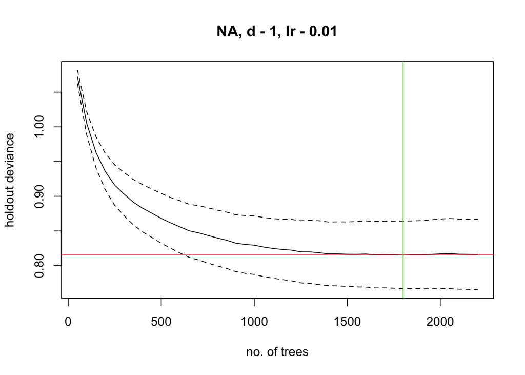

```
mean total deviance = 1.198
mean residual deviance = 0.614

estimated cv deviance = 0.816 ; se = 0.049

training data correlation = 0.758
cv correlation =  0.612 ; se = 0.032

training data AUC score = 0.933
cv AUC score = 0.861 ; se = 0.022

elapsed time -  0.08 minutes
```

```r
# cross-validation optimisation of a boosted regression tree model
brt <- gbm.step(data = PA,
                 gbm.x = 6:ncol(PA),
                 gbm.y = "presabs",
                 family = "bernoulli")
```

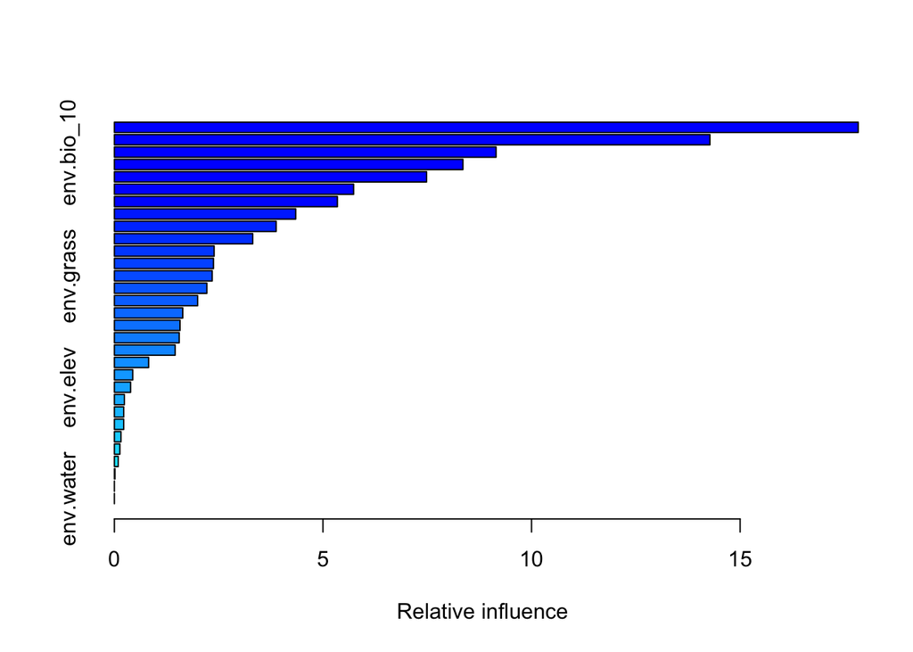

```
                              var     rel.inf
env.npp                   env.npp 17.83114532
env.urban               env.urban 14.27635566
env.bio_10             env.bio_10  9.15034431
env.woodysavanna env.woodysavanna  8.35544647
env.bio_7               env.bio_7  7.48381244
env.bio_15             env.bio_15  5.73491065
env.bio_19             env.bio_19  5.34572418
env.bio_13             env.bio_13  4.34743419
env.bio_4               env.bio_4  3.87811320
env.bio_8               env.bio_8  3.31703777
env.bio_12             env.bio_12  2.39149547
env.nonveg             env.nonveg  2.37578530
env.grass               env.grass  2.34507887
env.bio_5               env.bio_5  2.21706971
env.bio_6               env.bio_6  1.99516804
env.bio_14             env.bio_14  1.63855369
env.bio_3               env.bio_3  1.57330260
env.bio_9               env.bio_9  1.55339313
env.bio_11             env.bio_11  1.45618904
env.bio_1               env.bio_1  0.82047194
env.tree                 env.tree  0.44038147
env.elev                 env.elev  0.38908371
env.bio_18             env.bio_18  0.23996265
env.savanna           env.savanna  0.22380895
env.bio_16             env.bio_16  0.22353044
env.bio_2               env.bio_2  0.15833191
env.wetland           env.wetland  0.13165255
env.bio_17             env.bio_17  0.09198333
env.nontree           env.nontree  0.01443304
env.barren             env.barren  0.00000000
env.water               env.water  0.00000000
```

```r
summary(brt)
```

```r
variables_brt <- brt$contributions[1:6,] %>% pull(var)
#exploration of shape of relationships
#gbm.plot(brt, n.plots = 12, plot.layout=c(6, 2))
```

### Random forest

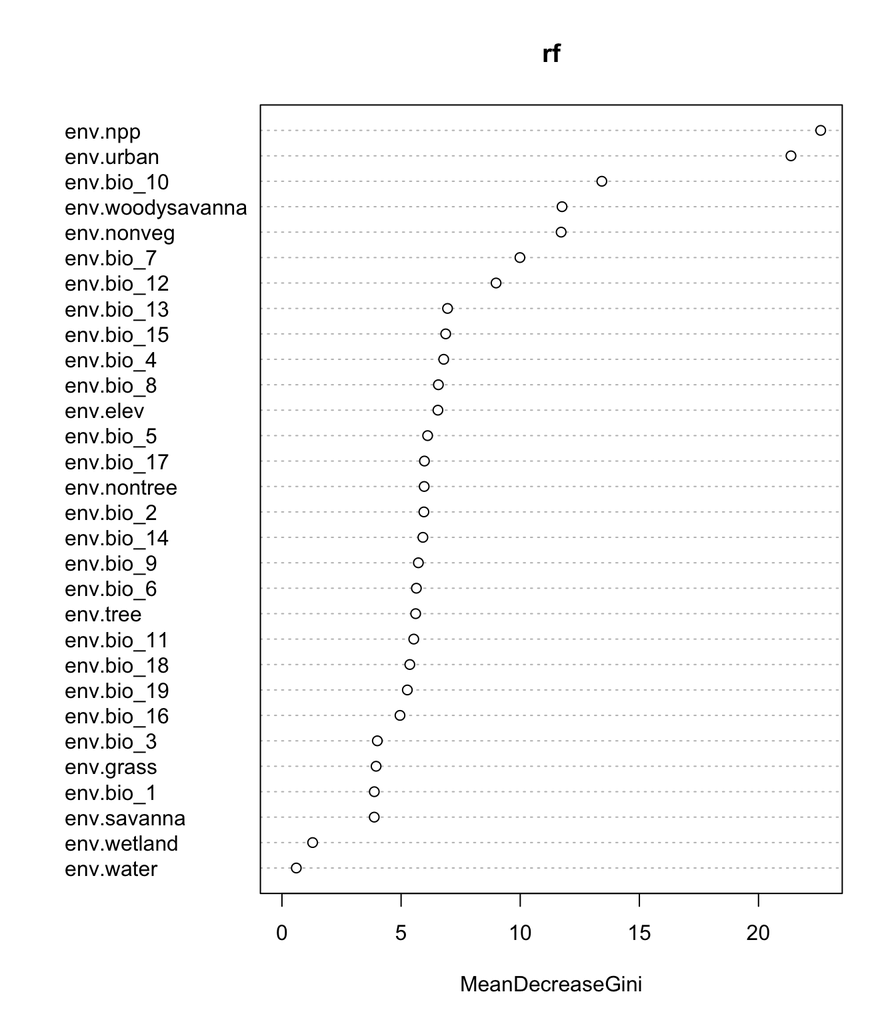

```r
presabs.rf <- PA %>%
  dplyr::select(-c(1,2,3,5)) %>%
  mutate(presabs = as.factor(presabs))

rf <- randomForest(presabs ~ .,
                   data=presabs.rf,
                   importance=T,
                   nperm=2, # two permutations per tree to estimate importance
                   na.action=na.omit,
                   mtry= 1/3*ncol(presabs.rf)-1)

varImpPlot(rf, type=2)
```

```r
variables_rf <- rf$importance %>% as_tibble(rownames = 'var') %>% arrange(desc(MeanDecreaseGini)) %>% head(n=6) %>% pull(var)
```

### Ranger

```r
presabs.ranger <- PA %>%
  dplyr::select(-c(1,2,3,5)) %>%
  filter(!if_any(everything(), is.na)) %>%
  mutate(presabs = as.factor(presabs))

## Learn the model:
ranger <- ranger(presabs ~ .,
                 data = presabs.ranger,
                 num.trees = 150,
                 mtry = 1/3*ncol(presabs.ranger)-1,
                 min.node.size = 5,
                 max.depth = NULL,
                 write.forest = TRUE,
                 importance = "impurity")


# Get the variable importance
importance(ranger)
```

```
       env.bio_1        env.bio_2        env.bio_3        env.bio_4
       3.8514607        5.2151457        4.5540016        6.6828377
       env.bio_5        env.bio_6        env.bio_7        env.bio_8
       5.0036236        5.5358332        9.9736513        5.9021468
       env.bio_9       env.bio_10       env.bio_11       env.bio_12
       5.9200243       13.8523766        5.7313261        8.5808980
      env.bio_13       env.bio_14       env.bio_15       env.bio_16
       5.9393527        5.9435295        7.0753105        4.4871342
      env.bio_17       env.bio_18       env.bio_19         env.elev
       6.0649447        4.8714778        5.4273101        6.2978083
       env.urban       env.barren        env.water      env.savanna
      21.6804082        0.1160384        0.5719562        3.8881341
env.woodysavanna      env.wetland        env.grass          env.npp
       9.7020694        0.9944282        3.9717758       20.0199734
        env.tree      env.nontree       env.nonveg
       5.0232644        5.2345367       11.3224068
```

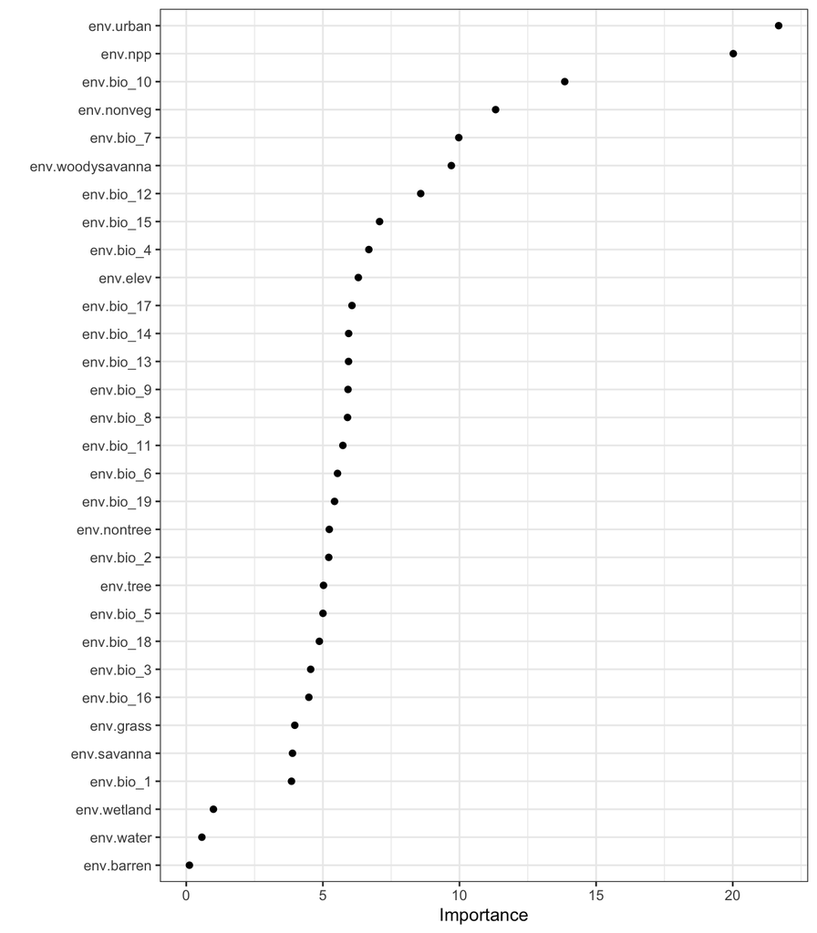

```r
importance(ranger) %>%
  as.data.frame(row.names = names(.)) %>%
  setNames(c("Importance")) %>%
  rownames_to_column("covariate") %>%
  # mutate(covariate = case_when(
  #   covariate == "env.bio_1" ~ "Annual Mean Temperature",
  # )) %>%
  ggplot(aes(x = Importance, y = reorder(covariate, Importance))) +
  ylab('')+
  geom_point() + theme_bw()
```

```r
variables_ranger <- importance(ranger) %>% as_tibble(rownames = 'var') %>% arrange(desc(value)) %>% head(n=6) %>% pull(var)
```

## Correlation

Correlation between the six more important variables detected.

- Boosted regression tree: env.npp, env.urban, env.bio_10, env.woodysavanna, env.bio_7, env.bio_15
- Random forest: env.npp, env.urban, env.bio_10, env.woodysavanna, env.nonveg, env.bio_7
- Ranger: env.urban, env.npp, env.bio_10, env.nonveg, env.bio_7, env.woodysavanna

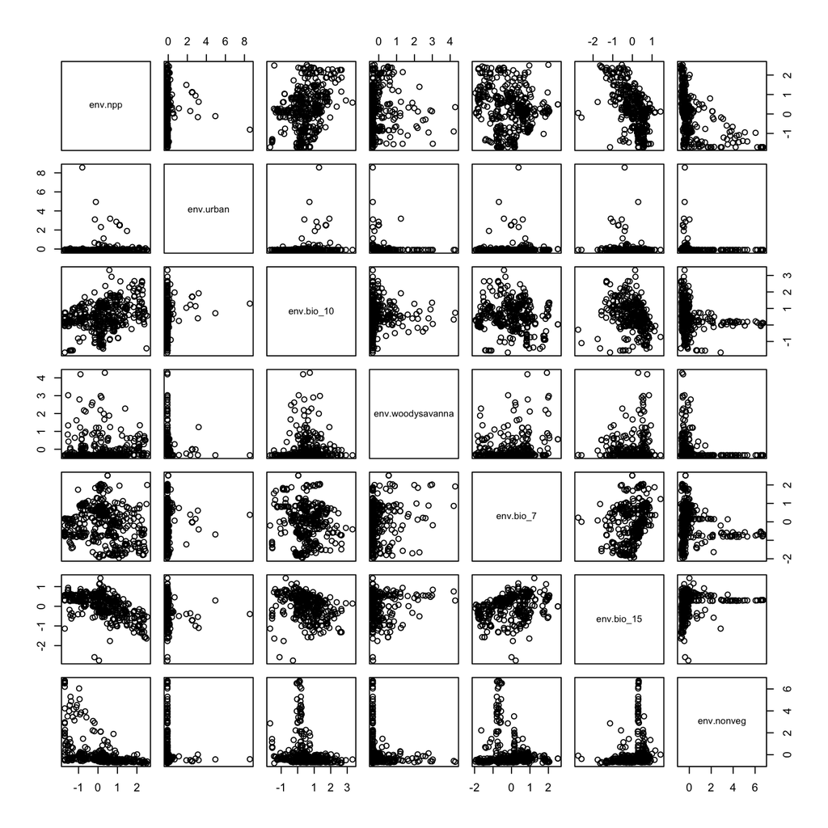

```r
selectedVariables <- unique(c(variables_brt, variables_rf, variables_ranger))

PA %>%
  filter(!if_any(everything(), is.na)) %>%
  dplyr::select(selectedVariables) %>%
  pairs()
```

```r
PA %>%
  filter(!if_any(everything(), is.na)) %>%
  dplyr::select(selectedVariables)  %>%
  cor() %>% kable()
```

|  | env.npp | env.urban | env.bio_10 | env.woodysavanna | env.bio_7 | env.bio_15 | env.nonveg |
| --- | --- | --- | --- | --- | --- | --- | --- |
| env.npp | 1.0000000 | 0.1381460 | 0.3063098 | 0.0352622 | -0.2081632 | -0.6021814 | -0.4770617 |
| env.urban | 0.1381460 | 1.0000000 | 0.2575487 | 0.0230751 | 0.0006525 | -0.2760903 | -0.0974461 |
| env.bio_10 | 0.3063098 | 0.2575487 | 1.0000000 | 0.0250223 | -0.1030469 | -0.4168521 | -0.2121246 |
| env.woodysavanna | 0.0352622 | 0.0230751 | 0.0250223 | 1.0000000 | 0.1607361 | 0.0320029 | -0.1180876 |
| env.bio_7 | -0.2081632 | 0.0006525 | -0.1030469 | 0.1607361 | 1.0000000 | 0.2926534 | -0.1459755 |
| env.bio_15 | -0.6021814 | -0.2760903 | -0.4168521 | 0.0320029 | 0.2926534 | 1.0000000 | 0.1983887 |
| env.nonveg | -0.4770617 | -0.0974461 | -0.2121246 | -0.1180876 | -0.1459755 | 0.1983887 | 1.0000000 |

```r
gc()
```

```
          used  (Mb) gc trigger  (Mb) limit (Mb) max used  (Mb)
Ncells 4708372 251.5    7292315 389.5         NA  7292315 389.5
Vcells 8744127  66.8   55121182 420.6     102400 68901431 525.7
```